[figure not shown]

[Image © 2009 20th Century Fox Film Corp.](https://en.wikipedia.org/wiki/File:Simpsons_FamilyPicture.png)

# TV Script Generation

In this project, you'll generate your own Simpsons TV scripts using RNNs. You'll be using part of the [Simpsons dataset](https://www.kaggle.com/wcukierski/the-simpsons-by-the-data) of scripts from 27 seasons. The Neural Network you'll build will generate a new TV script for a scene at [Moe's Tavern](https://simpsonswiki.com/wiki/Moe's_Tavern).

## Get the Data

The data is already provided for you. You'll be using a subset of the original dataset. It consists of only the scenes in Moe's Tavern. This doesn't include other versions of the tavern, like "Moe's Cavern", "Flaming Moe's", "Uncle Moe's Family Feed-Bag", etc..

```python
"""
DON'T MODIFY ANYTHING IN THIS CELL
"""
import helper

data_dir = './data/simpsons/moes_tavern_lines.txt'
text = helper.load_data(data_dir)
# Ignore notice, since we don't use it for analysing the data
text = text[81:]
```

## Explore the Data

Play around with `view_sentence_range` to view different parts of the data.

```python
view_sentence_range = (0, 10)

"""
DON'T MODIFY ANYTHING IN THIS CELL
"""
import numpy as np

print('Dataset Stats')
print('Roughly the number of unique words: {}'.format(len({word: None for word in text.split()})))
scenes = text.split('\n\n')
print('Number of scenes: {}'.format(len(scenes)))
sentence_count_scene = [scene.count('\n') for scene in scenes]
print('Average number of sentences in each scene: {}'.format(np.average(sentence_count_scene)))

sentences = [sentence for scene in scenes for sentence in scene.split('\n')]
print('Number of lines: {}'.format(len(sentences)))
word_count_sentence = [len(sentence.split()) for sentence in sentences]
print('Average number of words in each line: {}'.format(np.average(word_count_sentence)))

print()
print('The sentences {} to {}:'.format(*view_sentence_range))
print('\n'.join(text.split('\n')[view_sentence_range[0]:view_sentence_range[1]]))
```

```
Dataset Stats
Roughly the number of unique words: 11492
Number of scenes: 262
Average number of sentences in each scene: 15.248091603053435
Number of lines: 4257
Average number of words in each line: 11.50434578341555

The sentences 0 to 10:
Moe_Szyslak: (INTO PHONE) Moe's Tavern. Where the elite meet to drink.
Bart_Simpson: Eh, yeah, hello, is Mike there? Last name, Rotch.
Moe_Szyslak: (INTO PHONE) Hold on, I'll check. (TO BARFLIES) Mike Rotch. Mike Rotch. Hey, has anybody seen Mike Rotch, lately?
Moe_Szyslak: (INTO PHONE) Listen you little puke. One of these days I'm gonna catch you, and I'm gonna carve my name on your back with an ice pick.
Moe_Szyslak: What's the matter Homer? You're not your normal effervescent self.
Homer_Simpson: I got my problems, Moe. Give me another one.
Moe_Szyslak: Homer, hey, you should not drink to forget your problems.
Barney_Gumble: Yeah, you should only drink to enhance your social skills.
```

## Implement Preprocessing Functions

The first thing to do to any dataset is preprocessing. Implement the following preprocessing functions below:

- Lookup Table
- Tokenize Punctuation

### Lookup Table

To create a word embedding, you first need to transform the words to ids. In this function, create two dictionaries:

- Dictionary to go from the words to an id, we'll call `vocab_to_int`
- Dictionary to go from the id to word, we'll call `int_to_vocab`

Return these dictionaries in the following tuple `(vocab_to_int, int_to_vocab)`

```python
import numpy as np
import problem_unittests as tests

def create_lookup_tables(text):
    """
    Create lookup tables for vocabulary
    :param text: The text of tv scripts split into words
    :return: A tuple of dicts (vocab_to_int, int_to_vocab)
    """

    # TODO: Implement Function

    vocab = sorted(set(text))
    vocab_to_int = {word: index for index, word in enumerate(vocab)}
    int_to_vocab = dict(enumerate(vocab))

    return vocab_to_int, int_to_vocab


"""
DON'T MODIFY ANYTHING IN THIS CELL THAT IS BELOW THIS LINE
"""
tests.test_create_lookup_tables(create_lookup_tables)
```

```
Tests Passed
```

## Optional - Text analysis

```python
from collections import Counter

words = sentences.copy()
cleaned_words = [row.translate({ord(i):'' for i in '\'"():,.!?@#$\n'}) for row in words]

print("Original text")
print(words[:10])
print("\nCleaned text:")
print(cleaned_words[:10])

word_list = []

for row in cleaned_words:
    for word in row:
        word_list.append(word)

word_list = ''.join(word_list)
word_list = word_list.split()

total_count = len(word_list)
word_counter = Counter(word_list)
frequencies = [count/total_count for word, count in word_counter.items()]
freq_indices = np.argsort(-np.array(frequencies))

vocab_to_int, int_to_vocab = create_lookup_tables(word_list)

print("\nOverview of most common words:")

count = 0
for index in freq_indices:
    word = word_list[index]
    print("{} {} {:0.1f}%".format(word, index, frequencies[index]*100))
    count += 1
    if count==15:
        break
```

```
Original text
["Moe_Szyslak: (INTO PHONE) Moe's Tavern. Where the elite meet to drink.", 'Bart_Simpson: Eh, yeah, hello, is Mike there? Last name, Rotch.', "Moe_Szyslak: (INTO PHONE) Hold on, I'll check. (TO BARFLIES) Mike Rotch. Mike Rotch. Hey, has anybody seen Mike Rotch, lately?", "Moe_Szyslak: (INTO PHONE) L…

Cleaned text:
['Moe_Szyslak INTO PHONE Moes Tavern Where the elite meet to drink', 'Bart_Simpson Eh yeah hello is Mike there Last name Rotch', 'Moe_Szyslak INTO PHONE Hold on Ill check TO BARFLIES Mike Rotch Mike Rotch Hey has anybody seen Mike Rotch lately', 'Moe_Szyslak INTO PHONE Listen you little puke One of …

Overview of most common words:
the 5553 2.8%
a 4211 2.5%
worth 7933 2.1%
next 9289 2.1%
back 6876 1.7%
know 2969 1.0%
Moe_Szyslak 0 0.9%
face 402 0.9%
a 8571 0.8%
my 9788 0.8%
Wow 3511 0.7%
off 6673 0.7%
man 8731 0.7%
family 6151 0.7%
Oh 8683 0.7%
```

### Tokenize Punctuation

We'll be splitting the script into a word array using spaces as delimiters. However, punctuations like periods and exclamation marks make it hard for the neural network to distinguish between the word "bye" and "bye!".

Implement the function `token_lookup` to return a dict that will be used to tokenize symbols like "!" into "||Exclamation_Mark||". Create a dictionary for the following symbols where the symbol is the key and value is the token:

- Period ( . )
- Comma ( , )
- Quotation Mark ( " )
- Semicolon ( ; )
- Exclamation mark ( ! )
- Question mark ( ? )
- Left Parentheses ( ( )
- Right Parentheses ( ) )
- Dash ( -- )
- Return ( \n )

This dictionary will be used to token the symbols and add the delimiter (space) around it. This separates the symbols as it's own word, making it easier for the neural network to predict on the next word. Make sure you don't use a token that could be confused as a word. Instead of using the token "dash", try using something like "||dash||".

```python
def token_lookup():
    """
    Generate a dict to turn punctuation into a token.
    :return: Tokenize dictionary where the key is the punctuation and the value is the token
    """

    # TODO Implement symbol to token conversion

    symbol_to_token = {'.' : '||Period||',
                       ',' : '||Comma||',
                       '"' : '||QuotationMark||',
                       ';' : '||Semicolon||',
                       '!' : '||ExclamationMark||',
                        '?': '||QuestionMark||',
                        '(': '||LeftParentheses||',
                        ')': '||RightParentheses||',
                        '--': '||Dash||',
                        '\n' : '||Return||'}

    # token_to_symbol = {token: key for value, key in symbol_to_token}

    return symbol_to_token

"""
DON'T MODIFY ANYTHING IN THIS CELL THAT IS BELOW THIS LINE
"""
tests.test_tokenize(token_lookup)
```

```
Tests Passed
```

## Tests

```python
lookup = token_lookup()

for token in ['.',',', '"',';','!','?','(', ')', '--', '\n']:
    print("{} --> {}".format('(return)' if token=='\n' else token, lookup[token]))
```

```
. --> ||Period||
, --> ||Comma||
" --> ||QuotationMark||
; --> ||Semicolon||
! --> ||ExclamationMark||
? --> ||QuestionMark||
( --> ||LeftParentheses||
) --> ||RightParentheses||
-- --> ||Dash||
(return) --> ||Return||
```

## Preprocess all the data and save it

Running the code cell below will preprocess all the data and save it to file.

```python
"""
DON'T MODIFY ANYTHING IN THIS CELL
"""
# Preprocess Training, Validation, and Testing Data
helper.preprocess_and_save_data(data_dir, token_lookup, create_lookup_tables)
```

# Check Point

This is your first checkpoint. If you ever decide to come back to this notebook or have to restart the notebook, you can start from here. The preprocessed data has been saved to disk.

```python
"""
DON'T MODIFY ANYTHING IN THIS CELL
"""
import helper
import numpy as np
import problem_unittests as tests

int_text, vocab_to_int, int_to_vocab, token_dict = helper.load_preprocess()
```

## Build the Neural Network

You'll build the components necessary to build a RNN by implementing the following functions below:

- get_inputs
- get_init_cell
- get_embed
- build_rnn
- build_nn
- get_batches

### Check the Version of TensorFlow and Access to GPU

```python
"""
DON'T MODIFY ANYTHING IN THIS CELL
"""
from distutils.version import LooseVersion
import warnings
import tensorflow as tf

# Check TensorFlow Version
assert LooseVersion(tf.__version__) >= LooseVersion('1.0'), 'Please use TensorFlow version 1.0 or newer'
print('TensorFlow Version: {}'.format(tf.__version__))

# Check for a GPU
if not tf.test.gpu_device_name():
    warnings.warn('No GPU found. Please use a GPU to train your neural network.')
else:
    print('Default GPU Device: {}'.format(tf.test.gpu_device_name()))
```

```
TensorFlow Version: 1.1.0
Default GPU Device: /gpu:0
```

### Input

Implement the `get_inputs()` function to create TF Placeholders for the Neural Network. It should create the following placeholders:

- Input text placeholder named "input" using the [TF Placeholder](https://www.tensorflow.org/api_docs/python/tf/placeholder) `name` parameter.
- Targets placeholder
- Learning Rate placeholder

Return the placeholders in the following tuple `(Input, Targets, LearningRate)`

```python
def get_inputs():
    """
    Create TF Placeholders for input, targets, and learning rate.
    :return: Tuple (input, targets, learning rate)
    """
    # TODO: Implement Function

    # Input is a list of sequences of words
    input = tf.placeholder(tf.int32, [None, None], name='input')
    # Training target is a shifted sequence, see batch creation function below
    targets = tf.placeholder(tf.int32, [None, None], name='targets')
    # Learning rate, will later be defined below in the hyperparameters section
    learning_rate = tf.placeholder(tf.float32, name = 'learning_rate')

    return input, targets, learning_rate


"""
DON'T MODIFY ANYTHING IN THIS CELL THAT IS BELOW THIS LINE
"""
tests.test_get_inputs(get_inputs)
```

```
Tests Passed
```

### Build RNN Cell and Initialize

Stack one or more [`BasicLSTMCells`](https://www.tensorflow.org/api_docs/python/tf/contrib/rnn/BasicLSTMCell) in a [`MultiRNNCell`](https://www.tensorflow.org/api_docs/python/tf/contrib/rnn/MultiRNNCell).

- The Rnn size should be set using `rnn_size`
- Initalize Cell State using the MultiRNNCell's [`zero_state()`](https://www.tensorflow.org/api_docs/python/tf/contrib/rnn/MultiRNNCell#zero_state) function
  - Apply the name "initial_state" to the initial state using [`tf.identity()`](https://www.tensorflow.org/api_docs/python/tf/identity)

Return the cell and initial state in the following tuple `(Cell, InitialState)`

```python
# Constant hyper parameters

# Chance by which a neuron is kept active. 70% led to very satisfying results
training_dropout_keep = 0.7

# Count of RNN layers
rnn_layers = 2
```

```python
def create_cell(rnn_size):
        lstm = tf.contrib.rnn.BasicLSTMCell(rnn_size)
        drop = tf.contrib.rnn.DropoutWrapper(lstm, output_keep_prob=training_dropout_keep)
        return drop

def get_init_cell(batch_size, rnn_size):
    """
    Create an RNN Cell and initialize it.
    :param batch_size: Size of batches
    :param rnn_size: Size of RNNs
    :return: Tuple (cell, initialize state)
    """

    # TODO: Implement Function
    cell = tf.contrib.rnn.MultiRNNCell([create_cell(rnn_size) for i in range(rnn_layers)])

    zero_state = cell.zero_state(batch_size, tf.float32)
    initial_state = tf.identity(zero_state, name="initial_state")

    return cell, initial_state


"""
DON'T MODIFY ANYTHING IN THIS CELL THAT IS BELOW THIS LINE
"""
tests.test_get_init_cell(get_init_cell)
```

```
Tests Passed
```

### Word Embedding

Apply embedding to `input_data` using TensorFlow. Return the embedded sequence.

```python
def get_embed(input_data, vocab_size, embed_dim):
    """
    Create embedding for <input_data>.
    :param input_data: TF placeholder for text input.
    :param vocab_size: Number of words in vocabulary.
    :param embed_dim: Number of embedding dimensions
    :return: Embedded input.
    """

    # TODO: Implement Function

    embedding = tf.Variable(initial_value=tf.random_uniform(shape=[vocab_size, embed_dim], minval=-1.0, maxval=1.0))
    embed = tf.nn.embedding_lookup(embedding, input_data)
    return embed

"""
DON'T MODIFY ANYTHING IN THIS CELL THAT IS BELOW THIS LINE
"""
tests.test_get_embed(get_embed)
```

```
Tests Passed
```

### Build RNN

You created a RNN Cell in the `get_init_cell()` function. Time to use the cell to create a RNN.

- Build the RNN using the [`tf.nn.dynamic_rnn()`](https://www.tensorflow.org/api_docs/python/tf/nn/dynamic_rnn)
  - Apply the name "final_state" to the final state using [`tf.identity()`](https://www.tensorflow.org/api_docs/python/tf/identity)

Return the outputs and final_state state in the following tuple `(Outputs, FinalState)`

```python
def build_rnn(cell, inputs):
    """
    Create a RNN using a RNN Cell
    :param cell: RNN Cell
    :param inputs: Input text data
    :return: Tuple (Outputs, Final State)
    """
    # TODO: Implement Function

    # Construct dynamic neural network
    outputs, state = tf.nn.dynamic_rnn(cell, inputs, dtype=tf.float32)
    # Setup initial state
    state = tf.identity(state, name='final_state')

    return outputs, state


"""
DON'T MODIFY ANYTHING IN THIS CELL THAT IS BELOW THIS LINE
"""
tests.test_build_rnn(build_rnn)
```

```
Tests Passed
```

### Build the Neural Network

Apply the functions you implemented above to:

- Apply embedding to `input_data` using your `get_embed(input_data, vocab_size, embed_dim)` function.
- Build RNN using `cell` and your `build_rnn(cell, inputs)` function.
- Apply a fully connected layer with a linear activation and `vocab_size` as the number of outputs.

Return the logits and final state in the following tuple (Logits, FinalState)

```python
def build_nn(cell, rnn_size, input_data, vocab_size, embed_dim):
    """
    Build part of the neural network
    :param cell: RNN cell
    :param rnn_size: Size of rnns
    :param input_data: Input data
    :param vocab_size: Vocabulary size
    :param embed_dim: Number of embedding dimensions
    :return: Tuple (Logits, FinalState)
    """
    # TODO: Implement Function

    # Setup RNN
    inputs = get_embed(input_data, vocab_size, embed_dim)
    outputs, final_state = build_rnn(cell, inputs)
    # Setup fully connected layer
    logits = tf.contrib.layers.fully_connected(outputs, vocab_size, activation_fn=None)

    return logits, final_state


"""
DON'T MODIFY ANYTHING IN THIS CELL THAT IS BELOW THIS LINE
"""
tests.test_build_nn(build_nn)
```

```
Tests Passed
```

### Batches

Implement `get_batches` to create batches of input and targets using `int_text`. The batches should be a Numpy array with the shape `(number of batches, 2, batch size, sequence length)`. Each batch contains two elements:

- The first element is a single batch of **input** with the shape `[batch size, sequence length]`
- The second element is a single batch of **targets** with the shape `[batch size, sequence length]`

If you can't fill the last batch with enough data, drop the last batch.

For exmple, `get_batches([1, 2, 3, 4, 5, 6, 7, 8, 9, 10, 11, 12, 13, 14, 15, 16, 17, 18, 19, 20], 3, 2)` would return a Numpy array of the following:

```
[
  # First Batch
  [
    # Batch of Input
    [[ 1  2], [ 7  8], [13 14]]
    # Batch of targets
    [[ 2  3], [ 8  9], [14 15]]
  ]

  # Second Batch
  [
    # Batch of Input
    [[ 3  4], [ 9 10], [15 16]]
    # Batch of targets
    [[ 4  5], [10 11], [16 17]]
  ]

  # Third Batch
  [
    # Batch of Input
    [[ 5  6], [11 12], [17 18]]
    # Batch of targets
    [[ 6  7], [12 13], [18  1]]
  ]
]
```

Notice that the last target value in the last batch is the first input value of the first batch. In this case, `1`. This is a common technique used when creating sequence batches, although it is rather unintuitive.

```python
def get_batches(int_text, batch_size, seq_length):
    """
    Return batches of input and target
    :param int_text: Text with the words replaced by their ids
    :param batch_size: The size of batch
    :param seq_length: The length of sequence
    :return: Batches as a Numpy array
    """

    full_batch_size = batch_size*seq_length # effetive size per batch
    full_batch_count = len(int_text)//full_batch_size # count of possible batches
    column_size = full_batch_count*seq_length # size/offset caused by column eg 6 = 3*2 in the example above

    batches = []

    max_ind = full_batch_count*full_batch_size

     # for all full batches
    for fbi in range(full_batch_count):
        batch = []
        input_data = []
        output_data = []

        full_batch_off = fbi*seq_length

        for bi in range(batch_size):
            batch_off = bi*column_size + full_batch_off # eg 6 for the second columm

            input_data.append(np.array([int_text[batch_off+seq] for seq in range(seq_length)]))
            output_data.append(np.array([int_text[(batch_off+seq+1)%max_ind] for seq in range(seq_length)]))

        batch.append(np.array(input_data))
        batch.append(np.array(output_data))
        batches.append(np.array(batch))

    return np.array(batches)

"""
DON'T MODIFY ANYTHING IN THIS CELL THAT IS BELOW THIS LINE
"""
tests.test_get_batches(get_batches)
```

```
Tests Passed
```

## Optional - Verification

```python
original = [1, 2, 3, 4, 5, 6, 7, 8, 9, 10, 11, 12, 13, 14, 15, 16, 17, 18, 19, 20]
print("{} \n\n {}".format(original,get_batches(original, 3, 2)))
```

```
[1, 2, 3, 4, 5, 6, 7, 8, 9, 10, 11, 12, 13, 14, 15, 16, 17, 18, 19, 20]

 [[[[ 1  2]
   [ 7  8]
   [13 14]]

  [[ 2  3]
   [ 8  9]
   [14 15]]]


 [[[ 3  4]
   [ 9 10]
   [15 16]]

  [[ 4  5]
   [10 11]
   [16 17]]]


 [[[ 5  6]
   [11 12]
   [17 18]]

  [[ 6  7]
   [12 13]
   [18  1]]]]
```

## Neural Network Training

### Hyperparameters

Tune the following parameters:

- Set `num_epochs` to the number of epochs.
- Set `batch_size` to the batch size.
- Set `rnn_size` to the size of the RNNs.
- Set `embed_dim` to the size of the embedding.
- Set `seq_length` to the length of sequence.
- Set `learning_rate` to the learning rate.
- Set `show_every_n_batches` to the number of batches the neural network should print progress.

```python
# Number of Epochs
num_epochs = 100
# Batch Size
batch_size = 128
# RNN Size
rnn_size = 1024
# Embedding Dimension Size
embed_dim = 512
# Sequence Length
seq_length = 16
# Learning Rate
learning_rate = 0.001
# Show stats for every n number of epochs
show_every_n_epochs = 5

"""
DON'T MODIFY ANYTHING IN THIS CELL THAT IS BELOW THIS LINE
"""
save_dir = './save'
```

### Build the Graph

Build the graph using the neural network you implemented.

```python
"""
DON'T MODIFY ANYTHING IN THIS CELL
"""
from tensorflow.contrib import seq2seq

train_graph = tf.Graph()
with train_graph.as_default():
    vocab_size = len(int_to_vocab)
    input_text, targets, lr = get_inputs()
    input_data_shape = tf.shape(input_text)
    cell, initial_state = get_init_cell(input_data_shape[0], rnn_size)
    logits, final_state = build_nn(cell, rnn_size, input_text, vocab_size, embed_dim)

    # Probabilities for generating words
    probs = tf.nn.softmax(logits, name='probs')

    # Loss function
    cost = seq2seq.sequence_loss(
        logits,
        targets,
        tf.ones([input_data_shape[0], input_data_shape[1]]))

    # Optimizer
    optimizer = tf.train.AdamOptimizer(lr)

    # Gradient Clipping
    gradients = optimizer.compute_gradients(cost)
    capped_gradients = [(tf.clip_by_value(grad, -1., 1.), var) for grad, var in gradients if grad is not None]
    train_op = optimizer.apply_gradients(capped_gradients)
```

## Train

Train the neural network on the preprocessed data. If you have a hard time getting a good loss, check the [forums](https://discussions.udacity.com/) to see if anyone is having the same problem.

```python
"""
DON'T MODIFY ANYTHING IN THIS CELL
"""
batches = get_batches(int_text, batch_size, seq_length)

loss_rate = []
epoch_index = []

with tf.Session(graph=train_graph) as sess:
    sess.run(tf.global_variables_initializer())

    for epoch_i in range(num_epochs):
        state = sess.run(initial_state, {input_text: batches[0][0]})

        for batch_i, (x, y) in enumerate(batches):
            feed = {
                input_text: x,
                targets: y,
                initial_state: state,
                lr: learning_rate}
            train_loss, state, _ = sess.run([cost, final_state, train_op], feed)

            # Show every <show_every_n_batches> batches
            if batch_i==0:
                loss_rate.append(train_loss)
                epoch_index.append(epoch_i)

                if epoch_i%show_every_n_epochs==0 or epoch_i==num_epochs-1:
                    print('Epoch {:>3} Batch {:>4}/{}   train_loss = {:.3f}'.format(
                        epoch_i,
                        batch_i,
                        len(batches),
                        train_loss))

    # Save Model
    saver = tf.train.Saver()
    saver.save(sess, save_dir)
    print('Model Trained and Saved')
```

```
Epoch   0 Batch    0/33   train_loss = 8.821
Epoch   5 Batch    0/33   train_loss = 4.772
Epoch  10 Batch    0/33   train_loss = 4.193
Epoch  15 Batch    0/33   train_loss = 3.650
Epoch  20 Batch    0/33   train_loss = 3.099
Epoch  25 Batch    0/33   train_loss = 2.582
Epoch  30 Batch    0/33   train_loss = 2.211
Epoch  35 Batch    0/33   train_loss = 1.701
Epoch  40 Batch    0/33   train_loss = 1.285
Epoch  45 Batch    0/33   train_loss = 0.991
Epoch  50 Batch    0/33   train_loss = 0.750
Epoch  55 Batch    0/33   train_loss = 0.575
Epoch  60 Batch    0/33   train_loss = 0.421
Epoch  65 Batch    0/33   train_loss = 0.367
Epoch  70 Batch    0/33   train_loss = 0.317
Epoch  75 Batch    0/33   train_loss = 0.285
Epoch  80 Batch    0/33   train_loss = 0.266
Epoch  85 Batch    0/33   train_loss = 0.252
Epoch  90 Batch    0/33   train_loss = 0.250
Epoch  95 Batch    0/33   train_loss = 0.238
Epoch  99 Batch    0/33   train_loss = 0.244
Model Trained and Saved
```

## Optional Visualization of training loss

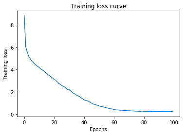

```python
%matplotlib inline
from matplotlib import pyplot as plt

plt.plot(epoch_index, loss_rate)
plt.xlabel("Epochs")
plt.title("Training loss curve")
plt.ylabel("Training loss")
plt.show()
```

## Save Parameters

Save `seq_length` and `save_dir` for generating a new TV script.

```python
"""
DON'T MODIFY ANYTHING IN THIS CELL
"""
# Save parameters for checkpoint
helper.save_params((seq_length, save_dir))
```

# Checkpoint

```python
"""
DON'T MODIFY ANYTHING IN THIS CELL
"""
import tensorflow as tf
import numpy as np
import helper
import problem_unittests as tests

_, vocab_to_int, int_to_vocab, token_dict = helper.load_preprocess()
seq_length, load_dir = helper.load_params()
```

## Implement Generate Functions

### Get Tensors

Get tensors from `loaded_graph` using the function [`get_tensor_by_name()`](https://www.tensorflow.org/api_docs/python/tf/Graph#get_tensor_by_name). Get the tensors using the following names:

- "input:0"
- "initial_state:0"
- "final_state:0"
- "probs:0"

Return the tensors in the following tuple `(InputTensor, InitialStateTensor, FinalStateTensor, ProbsTensor)`

```python
def get_tensors(loaded_graph):
    """
    Get input, initial state, final state, and probabilities tensor from <loaded_graph>
    :param loaded_graph: TensorFlow graph loaded from file
    :return: Tuple (InputTensor, InitialStateTensor, FinalStateTensor, ProbsTensor)
    """
    # TODO: Implement Function

    inputs = loaded_graph.get_tensor_by_name('input:0')
    initial_state = loaded_graph.get_tensor_by_name('initial_state:0')
    final_state = loaded_graph.get_tensor_by_name('final_state:0')
    probs = loaded_graph.get_tensor_by_name('probs:0')


    return inputs, initial_state, final_state, probs


"""
DON'T MODIFY ANYTHING IN THIS CELL THAT IS BELOW THIS LINE
"""
tests.test_get_tensors(get_tensors)
```

```
Tests Passed
```

### Choose Word

Implement the `pick_word()` function to select the next word using `probabilities`.

```python
import random

def pick_word(probabilities, int_to_vocab, randomness = 1):
    """
    Pick the next word in the generated text
    :param probabilities: Probabilites of the next word
    :param int_to_vocab: Dictionary of word ids as the keys and words as the values
    :return: String of the predicted word
    """
    # TODO: Implement Function

    max_top = randomness
    max_words = max_top if len(probabilities)>max_top else len(probabilities)
    # choose of a range of top words
    top_x = np.argpartition(probabilities,-max_words)[-max_words:]
    index = random.randint(0,max_words-1)
    # select final word of pool
    eff_index = top_x[index]

    # print(max_words)
    # print(len(probabilities))
    # print(top_x)
    # print(index)

    return int_to_vocab[eff_index]


"""
DON'T MODIFY ANYTHING IN THIS CELL THAT IS BELOW THIS LINE
"""
tests.test_pick_word(pick_word)
```

```
Tests Passed
```

## Optional - Test function

```python
# Following test should choose the banana
words = "Hello World Take The Banana And Nothing Else!"
weightings = [0,1,2,3,4,3,2,1]
print("Original text and word weightings: {} - {}".format(words, weightings))
print("\nSplit words:")
words = words.split()
print(words)
print("\nReconversion dictionary:")
word_dict = dict(enumerate(words))
print(word_dict)

print("\nHopefully a banana:")
print(pick_word(weightings, word_dict, randomness=1))
```

```
Original text and word weightings: Hello World Take The Banana And Nothing Else! - [0, 1, 2, 3, 4, 3, 2, 1]

Split words:
['Hello', 'World', 'Take', 'The', 'Banana', 'And', 'Nothing', 'Else!']

Reconversion dictionary:
{0: 'Hello', 1: 'World', 2: 'Take', 3: 'The', 4: 'Banana', 5: 'And', 6: 'Nothing', 7: 'Else!'}

Hopefully a banana:
Banana
```

## Generate TV Script

This will generate the TV script for you. Set `gen_length` to the length of TV script you want to generate.

```python
gen_length = 200
# homer_simpson, moe_szyslak, or Barney_Gumble
prime_word = 'moe_szyslak'

"""
DON'T MODIFY ANYTHING IN THIS CELL THAT IS BELOW THIS LINE
"""
loaded_graph = tf.Graph()
with tf.Session(graph=loaded_graph) as sess:
    # Load saved model
    loader = tf.train.import_meta_graph(load_dir + '.meta')
    loader.restore(sess, load_dir)

    # Get Tensors from loaded model
    input_text, initial_state, final_state, probs = get_tensors(loaded_graph)

    # Sentences generation setup
    gen_sentences = [prime_word + ':']
    prev_state = sess.run(initial_state, {input_text: np.array([[1]])})

    # Generate sentences
    for n in range(gen_length):
        # Dynamic Input
        dyn_input = [[vocab_to_int[word] for word in gen_sentences[-seq_length:]]]
        dyn_seq_length = len(dyn_input[0])

        # Get Prediction
        probabilities, prev_state = sess.run(
            [probs, final_state],
            {input_text: dyn_input, initial_state: prev_state})

        pred_word = pick_word(probabilities[dyn_seq_length-1], int_to_vocab)

        gen_sentences.append(pred_word)

    # Remove tokens
    tv_script = ' '.join(gen_sentences)
    for key, token in token_dict.items():
        ending = ' ' if key in ['\n', '(', '"'] else ''
        tv_script = tv_script.replace(' ' + token.lower(), key)
    tv_script = tv_script.replace('\n ', '\n')
    tv_script = tv_script.replace('( ', '(')

    print(tv_script)
```

```
INFO:tensorflow:Restoring parameters from ./save
```

[output not shown]

```
moe_szyslak:(chuckles) and now, homer, it's only fair that i give youse a little woman.
moe_szyslak:(simultaneous) eh is to 'em than being night with a war sangre!
chief_wiggum:(scared) i gotta take it.
walther_hotenhoffer: woo!
barney_gumble: geez, what be you need to offer myself the new world months to the south seas playhouse made him yesterday, but what did?
homer_simpson:(to self) someone's got a ticket, relaxing?
moe_szyslak: what?
moe_szyslak:(drunkenly) you're no more of a pig.
moe_szyslak:(happily) i gotta take it.
moe_szyslak:(to homer) i'm behind there.
chief_wiggum:(sad) you know, she could win my camera.(disgusted)
homer_simpson: i'm sweet what i don't want.
moe_szyslak: ma'am. i know how we're not down to my players club card... maxed on the ticket, uh, let me conclude now, we've gotta help you back.
barney_gumble: okay.
homer_simpson: put sweet home and spend
```

# The TV Script is Nonsensical

It's ok if the TV script doesn't make any sense. We trained on less than a megabyte of text. In order to get good results, you'll have to use a smaller vocabulary or get more data. Luckly there's more data! As we mentioned in the begging of this project, this is a subset of [another dataset](https://www.kaggle.com/wcukierski/the-simpsons-by-the-data). We didn't have you train on all the data, because that would take too long. However, you are free to train your neural network on all the data. After you complete the project, of course.

# Submitting This Project

When submitting this project, make sure to run all the cells before saving the notebook. Save the notebook file as "dlnd_tv_script_generation.ipynb" and save it as a HTML file under "File" -> "Download as". Include the "helper.py" and "problem_unittests.py" files in your submission.